# ML_LAB2_part2

Importing Libraries

```python
import numpy as np
import pandas as pd
from pandas import DataFrame as df
import matplotlib.pyplot as plt
from scipy import stats
import scipy.stats as ss
import seaborn as sns
```

Loading file

```python
filename = 'https://s3-api.us-geo.objectstorage.softlayer.net/cf-courses-data/CognitiveClass/DA0101EN/automobileEDA.csv'
```

```python
cars = pd.read_csv(filename)
```

```python
cars
```

|  | symboling | normalized-losses | make | aspiration | num-of-doors | body-style | drive-wheels | engine-location | wheel-base | length | ... | compression-ratio | horsepower | peak-rpm | city-mpg | highway-mpg | price | city-L/100km | horsepower-binned | diesel | gas |
| --- | --- | --- | --- | --- | --- | --- | --- | --- | --- | --- | --- | --- | --- | --- | --- | --- | --- | --- | --- | --- | --- |
| 0 | 3 | 122 | alfa-romero | std | two | convertible | rwd | front | 88.6 | 0.811148 | ... | 9.0 | 111.0 | 5000.0 | 21 | 27 | 13495.0 | 11.190476 | Medium | 0 | 1 |
| 1 | 3 | 122 | alfa-romero | std | two | convertible | rwd | front | 88.6 | 0.811148 | ... | 9.0 | 111.0 | 5000.0 | 21 | 27 | 16500.0 | 11.190476 | Medium | 0 | 1 |
| 2 | 1 | 122 | alfa-romero | std | two | hatchback | rwd | front | 94.5 | 0.822681 | ... | 9.0 | 154.0 | 5000.0 | 19 | 26 | 16500.0 | 12.368421 | Medium | 0 | 1 |
| 3 | 2 | 164 | audi | std | four | sedan | fwd | front | 99.8 | 0.848630 | ... | 10.0 | 102.0 | 5500.0 | 24 | 30 | 13950.0 | 9.791667 | Medium | 0 | 1 |
| 4 | 2 | 164 | audi | std | four | sedan | 4wd | front | 99.4 | 0.848630 | ... | 8.0 | 115.0 | 5500.0 | 18 | 22 | 17450.0 | 13.055556 | Medium | 0 | 1 |
| ... | ... | ... | ... | ... | ... | ... | ... | ... | ... | ... | ... | ... | ... | ... | ... | ... | ... | ... | ... | ... | ... |
| 196 | -1 | 95 | volvo | std | four | sedan | rwd | front | 109.1 | 0.907256 | ... | 9.5 | 114.0 | 5400.0 | 23 | 28 | 16845.0 | 10.217391 | Medium | 0 | 1 |
| 197 | -1 | 95 | volvo | turbo | four | sedan | rwd | front | 109.1 | 0.907256 | ... | 8.7 | 160.0 | 5300.0 | 19 | 25 | 19045.0 | 12.368421 | High | 0 | 1 |
| 198 | -1 | 95 | volvo | std | four | sedan | rwd | front | 109.1 | 0.907256 | ... | 8.8 | 134.0 | 5500.0 | 18 | 23 | 21485.0 | 13.055556 | Medium | 0 | 1 |
| 199 | -1 | 95 | volvo | turbo | four | sedan | rwd | front | 109.1 | 0.907256 | ... | 23.0 | 106.0 | 4800.0 | 26 | 27 | 22470.0 | 9.038462 | Medium | 1 | 0 |
| 200 | -1 | 95 | volvo | turbo | four | sedan | rwd | front | 109.1 | 0.907256 | ... | 9.5 | 114.0 | 5400.0 | 19 | 25 | 22625.0 | 12.368421 | Medium | 0 | 1 |

201 rows × 29 columns

Viewing DataTypes

```python
print("Dimensions are:")
print(cars.shape)
print("")
print("Datatypes:")
print(cars.dtypes)
```

```
Dimensions are:
(201, 29)

Datatypes:
symboling              int64
normalized-losses      int64
make                  object
aspiration            object
num-of-doors          object
body-style            object
drive-wheels          object
engine-location       object
wheel-base           float64
length               float64
width                float64
height               float64
curb-weight            int64
engine-type           object
num-of-cylinders      object
engine-size            int64
fuel-system           object
bore                 float64
stroke               float64
compression-ratio    float64
horsepower           float64
peak-rpm             float64
city-mpg               int64
highway-mpg            int64
price                float64
city-L/100km         float64
horsepower-binned     object
diesel                 int64
gas                    int64
dtype: object
```

Viewing correlation between variables 'price' and 'engine-size'

```python
correlation = cars.corr()
correlation['price']['engine-size']
```

```
0.8723351674455199
```

Checking for negative or positive correlation of variables with respect to price

```python
for i in cars.describe().columns:
    a = correlation['price'][i]
    if (a > 0 or a < 0):
        sign = "Positive"
        if (a < 0):
            sign = "Negative"
        else:
            sign = "Positive"
        print("Column name: {gog:s}      Correlation: {fog:s}".format(gog = i, fog = sign))
```

```
Column name: symboling      Correlation: Negative
Column name: normalized-losses      Correlation: Positive
Column name: wheel-base      Correlation: Positive
Column name: length      Correlation: Positive
Column name: width      Correlation: Positive
Column name: height      Correlation: Positive
Column name: curb-weight      Correlation: Positive
Column name: engine-size      Correlation: Positive
Column name: bore      Correlation: Positive
Column name: stroke      Correlation: Positive
Column name: compression-ratio      Correlation: Positive
Column name: horsepower      Correlation: Positive
Column name: peak-rpm      Correlation: Negative
Column name: city-mpg      Correlation: Negative
Column name: highway-mpg      Correlation: Negative
Column name: price      Correlation: Positive
Column name: city-L/100km      Correlation: Positive
Column name: diesel      Correlation: Positive
Column name: gas      Correlation: Negative
```

Checking datatype of variable 'peak-rpm'

```python
type(cars['peak-rpm'][1])
```

```
numpy.float64
```

Using seaborn regplot() - plot relation between “engine-size” and “price”.

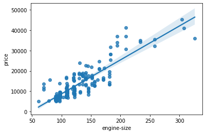

```python
sns.regplot('engine-size', 'price', data=cars)
```

Engine size and price are positively correlated.Checking pandas scatter_matrix

```python
from pandas.plotting import scatter_matrix
```

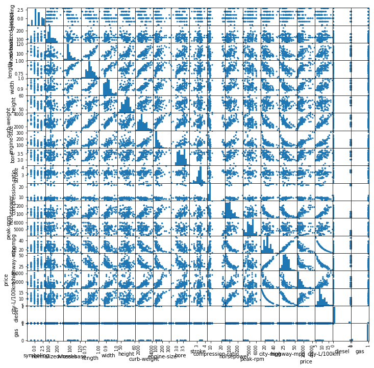

```python
scatter_matrix(cars, alpha = 1, figsize = (12,12));
```

Viewing individual - variable Regplot

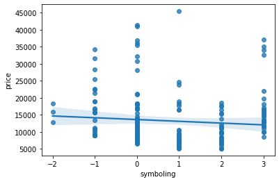

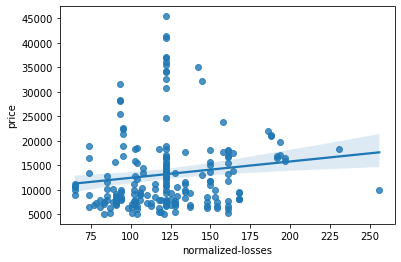

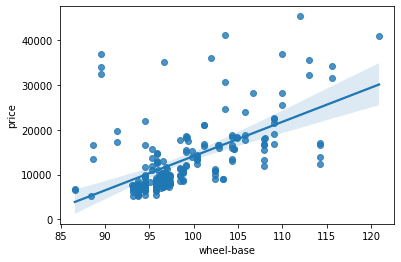

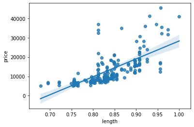

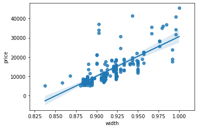

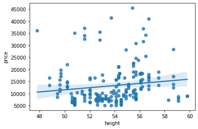

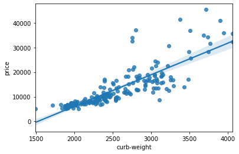

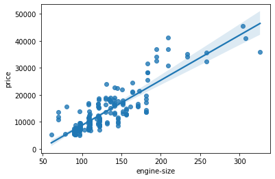

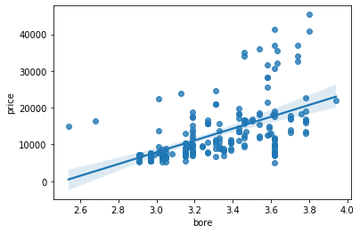

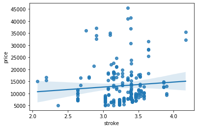

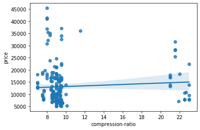

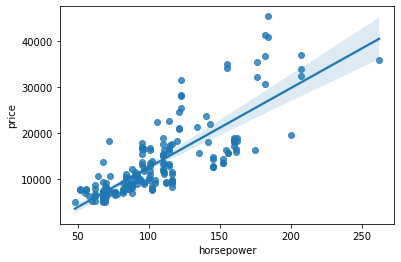

[6 more figures not shown]

```python
for i in cars.describe().columns:
    if i!='price':
        sns.regplot(y='price', x=i, data = cars)
        plt.show()
```

Using the SNS pairplot function

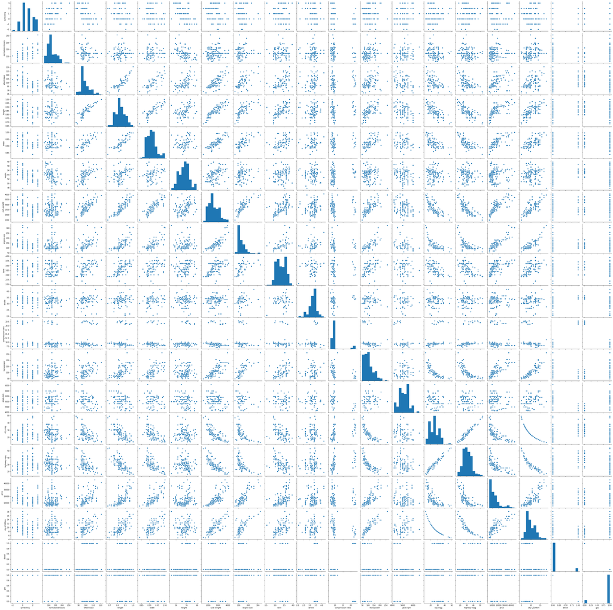

```python
sns.pairplot(cars);
```

Viewing Heatmap of the correlation

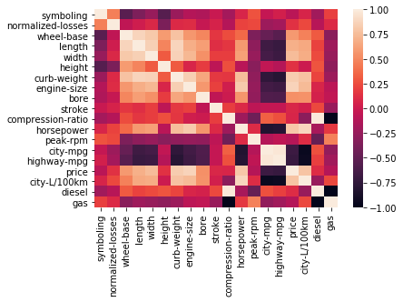

```python
sns.heatmap(correlation)
plt.show()
```

With seaborn boxplot() - comparing “body-style” with “price” and for other categorical variables

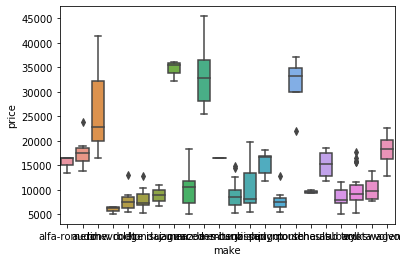

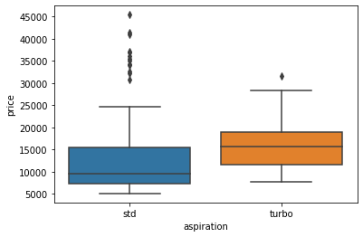

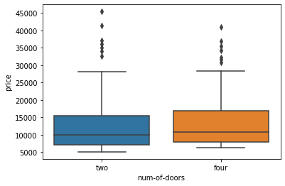

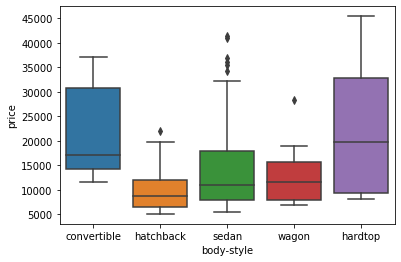

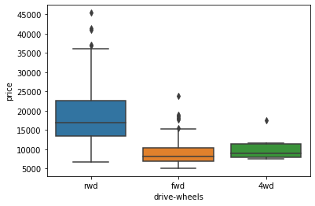

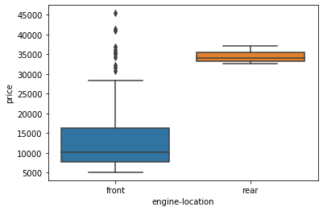

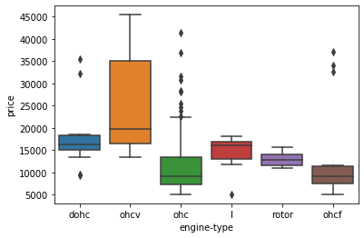

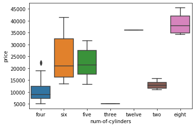

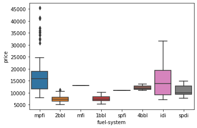

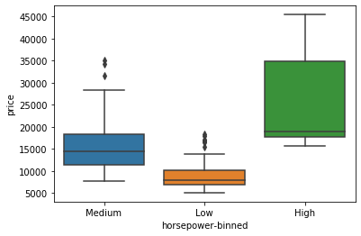

```python
for i in cars.describe(include = np.object).columns:
    sns.boxplot(x=cars[i], y=cars.price)
    plt.show()
```

```python
cars.describe()
```

|  | symboling | normalized-losses | wheel-base | length | width | height | curb-weight | engine-size | bore | stroke | compression-ratio | horsepower | peak-rpm | city-mpg | highway-mpg | price | city-L/100km | diesel | gas |
| --- | --- | --- | --- | --- | --- | --- | --- | --- | --- | --- | --- | --- | --- | --- | --- | --- | --- | --- | --- |
| count | 201.000000 | 201.00000 | 201.000000 | 201.000000 | 201.000000 | 201.000000 | 201.000000 | 201.000000 | 201.000000 | 197.000000 | 201.000000 | 201.000000 | 201.000000 | 201.000000 | 201.000000 | 201.000000 | 201.000000 | 201.000000 | 201.000000 |
| mean | 0.840796 | 122.00000 | 98.797015 | 0.837102 | 0.915126 | 53.766667 | 2555.666667 | 126.875622 | 3.330692 | 3.256904 | 10.164279 | 103.405534 | 5117.665368 | 25.179104 | 30.686567 | 13207.129353 | 9.944145 | 0.099502 | 0.900498 |
| std | 1.254802 | 31.99625 | 6.066366 | 0.059213 | 0.029187 | 2.447822 | 517.296727 | 41.546834 | 0.268072 | 0.319256 | 4.004965 | 37.365700 | 478.113805 | 6.423220 | 6.815150 | 7947.066342 | 2.534599 | 0.300083 | 0.300083 |
| min | -2.000000 | 65.00000 | 86.600000 | 0.678039 | 0.837500 | 47.800000 | 1488.000000 | 61.000000 | 2.540000 | 2.070000 | 7.000000 | 48.000000 | 4150.000000 | 13.000000 | 16.000000 | 5118.000000 | 4.795918 | 0.000000 | 0.000000 |
| 25% | 0.000000 | 101.00000 | 94.500000 | 0.801538 | 0.890278 | 52.000000 | 2169.000000 | 98.000000 | 3.150000 | 3.110000 | 8.600000 | 70.000000 | 4800.000000 | 19.000000 | 25.000000 | 7775.000000 | 7.833333 | 0.000000 | 1.000000 |
| 50% | 1.000000 | 122.00000 | 97.000000 | 0.832292 | 0.909722 | 54.100000 | 2414.000000 | 120.000000 | 3.310000 | 3.290000 | 9.000000 | 95.000000 | 5125.369458 | 24.000000 | 30.000000 | 10295.000000 | 9.791667 | 0.000000 | 1.000000 |
| 75% | 2.000000 | 137.00000 | 102.400000 | 0.881788 | 0.925000 | 55.500000 | 2926.000000 | 141.000000 | 3.580000 | 3.410000 | 9.400000 | 116.000000 | 5500.000000 | 30.000000 | 34.000000 | 16500.000000 | 12.368421 | 0.000000 | 1.000000 |
| max | 3.000000 | 256.00000 | 120.900000 | 1.000000 | 1.000000 | 59.800000 | 4066.000000 | 326.000000 | 3.940000 | 4.170000 | 23.000000 | 262.000000 | 6600.000000 | 49.000000 | 54.000000 | 45400.000000 | 18.076923 | 1.000000 | 1.000000 |

Using describe() to get stats of categorical variablesThe default setting of "describe" skips variables of type object. We can apply the method "describe" on the variables of type 'object' as follows:

```python
cars.describe(include=np.object)
```

|  | make | aspiration | num-of-doors | body-style | drive-wheels | engine-location | engine-type | num-of-cylinders | fuel-system | horsepower-binned |
| --- | --- | --- | --- | --- | --- | --- | --- | --- | --- | --- |
| count | 201 | 201 | 201 | 201 | 201 | 201 | 201 | 201 | 201 | 200 |
| unique | 22 | 2 | 2 | 5 | 3 | 2 | 6 | 7 | 8 | 3 |
| top | toyota | std | four | sedan | fwd | front | ohc | four | mpfi | Low |
| freq | 32 | 165 | 115 | 94 | 118 | 198 | 145 | 157 | 92 | 115 |

Getting unique values in each categorical variable along with their frequency.

```python
for i in cars.describe(include=np.object).columns:
    print(i)
    print(cars[i].value_counts())
    print("")
    print("")
```

```
make
toyota           32
nissan           18
mazda            17
mitsubishi       13
honda            13
subaru           12
volkswagen       12
peugot           11
volvo            11
dodge             9
bmw               8
mercedes-benz     8
plymouth          7
audi              6
saab              6
porsche           4
chevrolet         3
alfa-romero       3
jaguar            3
renault           2
isuzu             2
mercury           1
Name: make, dtype: int64


aspiration
std      165
turbo     36
Name: aspiration, dtype: int64


num-of-doors
four    115
two      86
Name: num-of-doors, dtype: int64


body-style
sedan          94
```

[output cut: 43 more lines]

```
2bbl    64
idi     20
1bbl    11
spdi     9
4bbl     3
mfi      1
spfi     1
Name: fuel-system, dtype: int64


horsepower-binned
Low       115
Medium     62
High       23
Name: horsepower-binned, dtype: int64
```

Value-counts is a good way of understanding how many units of each characteristic/variable we have. We can apply the "value_counts" method on the column 'drive-wheels'. Don’t forget the method "value_counts" only works on Pandas series, not Pandas Dataframes. As a result, we only include one bracket "df['drive-wheels']" not two brackets "df[['drive-wheels']]".Using groupby() to get the average price of “drive-wheels” wrt “price”

```python
for i in cars.describe(include=np.object).columns:
    print(cars.groupby(i)['price'].mean())
    print("")
    print("")
```

```
make
alfa-romero      15498.333333
audi             17859.166667
bmw              26118.750000
chevrolet         6007.000000
dodge             7875.444444
honda             8184.692308
isuzu             8916.500000
jaguar           34600.000000
mazda            10652.882353
mercedes-benz    33647.000000
mercury          16503.000000
mitsubishi        9239.769231
nissan           10415.666667
peugot           15489.090909
plymouth          7963.428571
porsche          31400.500000
renault           9595.000000
saab             15223.333333
subaru            8541.250000
toyota            9885.812500
volkswagen       10077.500000
volvo            18063.181818
Name: price, dtype: float64


aspiration
std      12542.181818
turbo    16254.805556
Name: price, dtype: float64


num-of-doors
four    13498.034783
two     12818.127907
Name: price, dtype: float64


body-style
convertible    21890.500000
```

[output cut: 43 more lines]

```
2bbl     7433.203125
4bbl    12145.000000
idi     15838.150000
mfi     12964.000000
mpfi    17605.141304
spdi    10990.444444
spfi    11048.000000
Name: price, dtype: float64


horsepower-binned
High      25899.130435
Low        9011.704348
Medium    15913.016129
Name: price, dtype: float64
```

The "groupby" method groups data by different categories. The data is grouped based on one or several variables and analysis is performed on the individual groups. From our data, it seems rear-wheel drive vehicles are, on average, the most expensive, while 4-wheel and front-wheel are approximately the same in price.

```python
cars.groupby(['drive-wheels','body-style'])['price'].mean()
```

```
drive-wheels  body-style
4wd           hatchback       7603.000000
              sedan          12647.333333
              wagon           9095.750000
fwd           convertible    11595.000000
              hardtop         8249.000000
              hatchback       8396.387755
              sedan           9811.800000
              wagon           9997.333333
rwd           convertible    23949.600000
              hardtop        24202.714286
              hatchback      14337.777778
              sedan          21711.833333
              wagon          16994.222222
Name: price, dtype: float64
```

```python
a = cars[['drive-wheels','body-style','price']]
pivot = a.groupby(['drive-wheels','body-style'], as_index=False).mean()
pivot_table = pivot.pivot(index = 'drive-wheels', columns = 'body-style')
pivot_table
```

| body-style drive-wheels | price convertible | price hardtop | price hatchback | price sedan | price wagon |
| --- | --- | --- | --- | --- | --- |
| 4wd | NaN | NaN | 7603.000000 | 12647.333333 | 9095.750000 |
| fwd | 11595.0 | 8249.000000 | 8396.387755 | 9811.800000 | 9997.333333 |
| rwd | 23949.6 | 24202.714286 | 14337.777778 | 21711.833333 | 16994.222222 |

```python
col = cars.describe(include=np.object).columns
redundant = []
for i in col:
    redundant.append(i)
    for j in col:
        if i==j or j in redundant:
            continue
        else:
            a = cars.groupby([i,j])['price'].mean()
            print(a, end='\n \n')
            a = cars[[i,j,'price']]
            pivot = a.groupby([i,j], as_index=False).mean()
            pivot = pivot.pivot(index = i, columns = j)
            pivot.replace(np.nan, '-', inplace= True)
            print('Pivot Table')
            print(pivot)
            print("")
            print("", end='\n\n')
```

```
make           aspiration
alfa-romero    std           15498.333333
audi           std           16656.000000
               turbo         23875.000000
bmw            std           26118.750000
chevrolet      std            6007.000000
dodge          std            6900.000000
               turbo          9826.333333
honda          std            8184.692308
isuzu          std            8916.500000
jaguar         std           34600.000000
mazda          std           10652.882353
mercedes-benz  std           38900.000000
               turbo         28394.000000
mercury        turbo         16503.000000
mitsubishi     std            7314.714286
               turbo         11485.666667
nissan         std            9869.588235
               turbo         19699.000000
peugot         std           14649.000000
               turbo         16189.166667
plymouth       std            7004.600000
               turbo         10360.500000
porsche        std           31400.500000
renault        std            9595.000000
saab           std           13642.500000
               turbo         18385.000000
subaru         std            7954.200000
               turbo         11476.500000
toyota         std            9859.612903
               turbo         10698.000000
volkswagen     std            9759.000000
               turbo         11670.000000
volvo          std           16197.500000
               turbo         20302.000000
Name: price, dtype: float64

Pivot Table
                 price
aspiration         std    turbo
```

[output cut: 1518 more lines]

```
spfi         Low                  11048.000000
Name: price, dtype: float64

Pivot Table
                     price
horsepower-binned     High      Low   Medium
fuel-system
1bbl                     -  7555.55        -
2bbl                     -   7433.2        -
4bbl                     -    12145        -
idi                      -  12047.8  27209.2
mfi                      -        -    12964
mpfi               25899.1  11871.9  15716.7
spdi                     -        -  10990.4
spfi                     -    11048        -
```

Observations :- We can see that there are no cars with medium or low horsepower which have their engine in rear. These are majorly the sports cars of segment. We also see that of all the segments, the cars having engine in the front and with low horsepower have the lowest average price of any car.

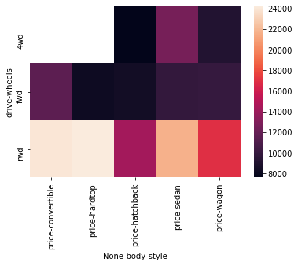

```python
sns.heatmap(pivot_table)
```

The heatmap plots the target variable (price) proportional to colour with respect to the variables 'drive-wheel' and 'body-style' in the vertical and horizontal axis respectively. This allows us to visualize how the price is related to 'drive-wheel' and 'body-style'.Using Pearson coeffecientThe Pearson Correlation measures the linear dependence between two variables X and Y. The resulting coefficient is a value between -1 and 1 inclusive, where: 1: Total positive linear correlation. 0: No linear correlation, the two variables most likely do not affect each other. -1: Total negative linear correlation.Wheel-base vs Price

```python
pearson_coeff, p_val = ss.pearsonr(cars['wheel-base'], cars['price'])
print(pearson_coeff, p_val)
```

```
0.584641822265508 8.076488270733218e-20
```

Since the p-value is < 0.001, the correlation between wheel-base and price is statistically significant, although the linear relationship isn't extremely strong (~0.585)Since ANOVA analyzes the difference between different groups of the same variable, the groupby function will come in handy. Because the ANOVA algorithm averages the data automatically, we do not need to take the average before hand. Let's see if different types 'drive-wheels' impact 'price', we group the data.

```python
a = cars[['drive-wheels', 'body-style','price']]
a = a[['drive-wheels', 'price']].groupby(['drive-wheels'])
a
f_val, p_val = stats.f_oneway(a.get_group('fwd')['price'],
                              a.get_group('4wd')['price'],
                              a.get_group('rwd')['price'])
print(f_val, p_val)
```

```
67.95406500780398 3.3945443577151245e-23
```

This is a great result, with a large F test score showing a strong correlation and a P value of almost 0 implying almost certain statistical significance.Separately: ANOVA RESULTS

```python
print("fwd and rwd")
f_val, p_val = stats.f_oneway(a.get_group('fwd')['price'], a.get_group('rwd')['price'])

print( "ANOVA results: F=", f_val, ", P =", p_val )

print("4wd and rwd")
f_val, p_val = stats.f_oneway(a.get_group('4wd')['price'], a.get_group('rwd')['price'])

print( "ANOVA results: F=", f_val, ", P =", p_val)

print("4wd and fwd")
f_val, p_val = stats.f_oneway(a.get_group('4wd')['price'], a.get_group('fwd')['price'])

print("ANOVA results: F=", f_val, ", P =", p_val)
```

```
fwd and rwd
ANOVA results: F= 130.5533160959111 , P = 2.2355306355677845e-23
4wd and rwd
ANOVA results: F= 8.580681368924756 , P = 0.004411492211225333
4wd and fwd
ANOVA results: F= 0.665465750252303 , P = 0.41620116697845666
```

We now have a better idea of what our data looks like and which variables are important to take into account when predicting the car price. We have narrowed it down to the following variables: Continuous numerical variables: Length Width Curb-weight Engine-size Horsepower City-mpg Highway-mpg Wheel-base Bore Categorical variables: Drive-wheels